# Emp: General Purpose Empirical Management Procedure

# 5 Equations

The Emp function follows a series of steps that go from index and catch calibration to index processing, the harvest control rule and finally the adjustment of a proposed TAC to meet various TAC change contraints.

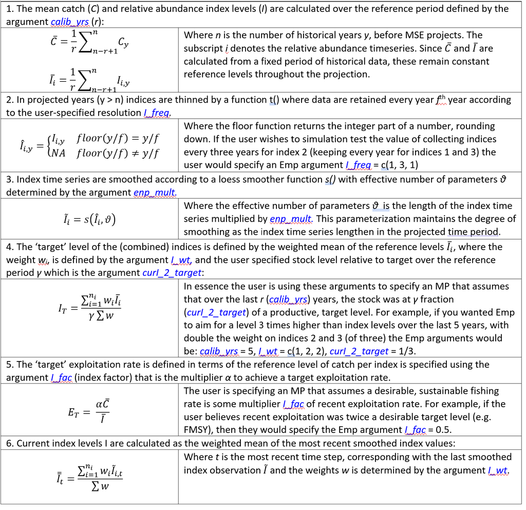

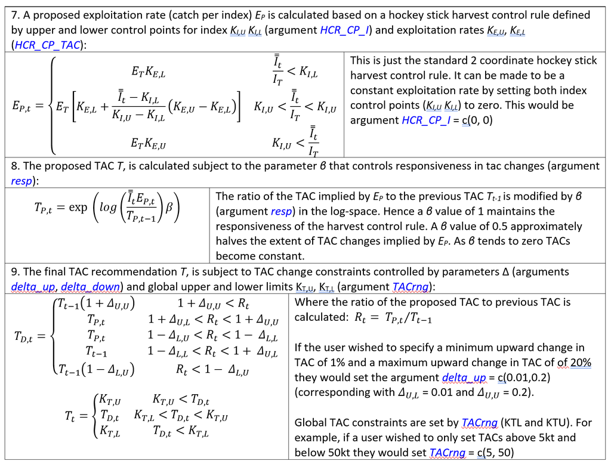

# 6 Emp code

Emp is intended to be a teaching tool but also as a starting point for making user-designed empirical MPs. The code is available from the command prompt and is reasonably straightforward to follow (takes the same steps as the equations above).

```r
Emp = function (x, Data, reps = 1, Inds = NA, I_freq = NA, I_wt = NA, calib_yrs = 2, enp_mult = 0.3,
                Ind_fac = NA, TACrng = NA,  delta_down = c(0.01, 0.5), delta_up = c(0.01, 0.5),
                resp = 1, curI_2_target = NA, HCR_CP_B = c(0, 0), HCR_CP_TAC = c(0, 1), Mode = 1){

    MPrec = Data@MPrec[x]
    ny = length(Data@Cat[x, ])
    ystart <- which(!is.na(Data@Cat[x, ]))[1]
    yind <- ystart:ny
    LHYr = Data@LHYear
    LHYrInd = match(LHYr, Data@Year)
    CurYr = max(Data@Year)
    Year <- Data@Year[yind]
    C_hist <- Data@Cat[x, yind]

    if (is.na(Inds[1])) {
        I_hist <- array(Data@Ind[x, yind], c(1, ny))
    } else {
        I_hist <- array(Data@AddInd[x, Inds, yind], c(length(Inds), ny))
    }

    nI = nrow(I_hist)

    if (is.na(I_freq[1])) I_freq = rep(1, nI)

    if (is.na(I_wt[1])) I_wt = rep(1, nI)

    if (is.na(Ind_fac)) {
        FMSY = Data@Misc$ReferencePoints$ByYear$FMSY[, LHYrInd]
        FM = Data@Misc$FleetPars$Find[, LHYrInd] * Data@Misc$FleetPars$qs
        Ind_fac = mean(FMSY/FM) * 0.75
    }

    if (is.na(curI_2_target)) {
        Dep = Data@Misc$StockPars$Depletion
        Brel = Data@Misc$StockPars$BMSY_B0
        curI_2_target = mean(Dep)/mean(Brel * 1.25)
    }

    if (is.na(TACrng))  TACrng = c(0, 100 * max(Data@Cat))

    I_keep = MSEtool::doIfreq(I_hist, I_freq, LHYr, CurYr, Year)
    caliby = LHYrInd - (calib_yrs - 1):0
    calibmuI = apply(I_keep[, caliby, drop = F], 1, mean, na.rm = T)
    ref = mean(calibmuI/curI_2_target, na.rm = T)
    calibmuC = mean(C_hist[caliby], na.rm = T)
    C_I = calibmuC/calibmuI
    nkeep = sum(I_freq != 0)
    I_smth = array(NA, c(nkeep, ny))

    for (j in 1:nkeep) I_smth[j, ] = MSEtool::smoothy(I_keep[j, ], enp_mult = enp_mult)

    est = weighted.mean(I_smth[, ny], I_wt, na.rm = T)

    if (Mode == 1) {
        TACbyI = I_smth[, ny] * C_I
        TACtemp = mean(TACbyI, na.rm = T) * Ind_fac
        if (is.na(TACtemp) | is.null(TACtemp))  TACtemp = Data@MPrec[x]
        trial_TAC = MSEtool::TACfilter(TACtemp)
        HCRadj_TAC = MSEtool::doHCR(trial_TAC, est = est, ref = ref, CP = HCR_CP_B, CPy = HCR_CP_TAC)
        mod = exp(log(HCRadj_TAC/MPrec) * resp)
    } else {
        mod = exp(log(est/ref) * resp)
    }

    MSEtool::doRec(MPrec, mod, delta_down, delta_up, TACrng)

}
```

# 7 References

[Butterworth, D.S. & Rademeyer, R. 2022. BR CMP AS AT JUNE 2022. Col. Vol. Sci. Pap. ICCAT. 79(3): 587-597](https://www.iccat.int/Documents/CVSP/CV079_2022/n_3/CV079030587.pdf)

[ICCAT 2024. North Atlantic Swordfish MSE: Final Results & Decision Guide. PA4_812/2024](https://www.iccat.int/com2024/ENG/PA4_812_ENG.pdf)